# Final Project: Academy Award Nominated Films, Violence, and the Bechdel Test

2026-05-05

### Esther Lim, Ethan Sanders, Kamilia Kwiatkowska

# Research Question

### Among the Oscar Academy Award Best Picture shortlisted films from 2020 to 2026, is there a significant relationship between a film’s IMDb Violence and Gore rating and the number of Bechdel Test criteria it meets?

# Hypotheses

### Hypothesis 1 (H1)

There is a statistically detectable relationship between a film’s IMDb Violence and Gore rating and the number of Bechdel Test criteria it meets among Oscar Best Picture shortlisted films (2020-2026).

# Findings

## Hypothesis 1

There is a statistically detectable relationship between a film’s IMDb Violence and Gore rating and the number of Bechdel Test criteria it meets among Oscar Best Picture shortlisted films (2020-2026).

### Median and Mean (H1)

```
## # A tibble: 4 × 5
##   violence     n   Mdn     M    SD
##   <ord>    <int> <dbl> <dbl> <dbl>
## 1 None        11     3  2.82 0.603
## 2 Mild        24     2  2.04 0.999
## 3 Moderate    18     3  2.5  0.857
## 4 Severe      14     3  2.14 1.23
```

### Scatter H1

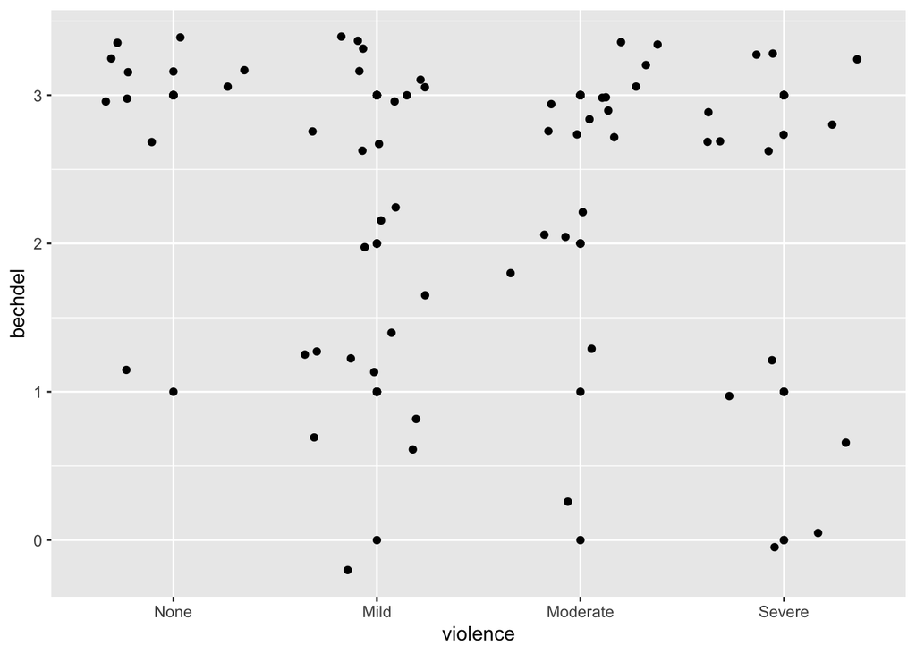

### Violin H1

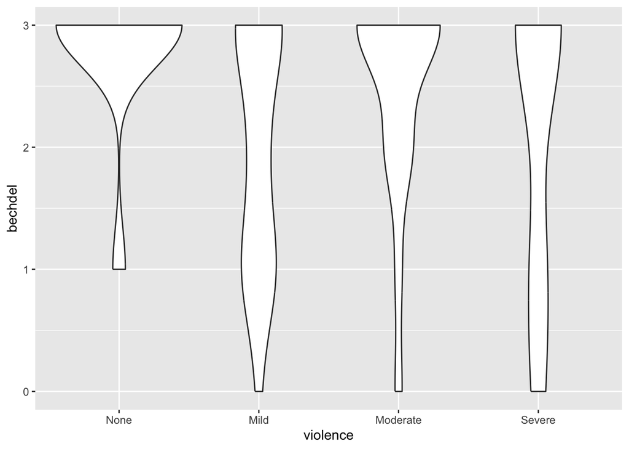

### Boxplot H1

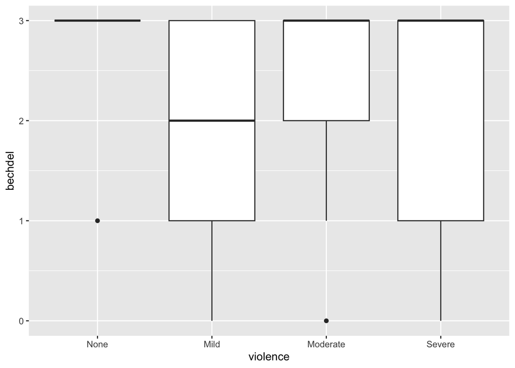

### Spearman Test H1

```
##
##  Spearman's rank correlation rho
##
## data:  bechdel and violence_coded
## S = 53861, p-value = 0.5478
## alternative hypothesis: true rho is not equal to 0
## sample estimates:
##         rho
## -0.07473071
```

### Findings H1

There is no real correlation between Bechdel Test criteria passed and violence scores for Academy Award Best Picture nominees, because p = 0.548. PLEASE CHECK.

# Hypothesis 2

H2 Of Best Picture nominees, winners of the Academy Award for Best Picture are more likely to pass Bechdel Test criteria.

### Median and Mean H2

```
## # A tibble: 2 × 5
##   result      n   Mdn     M    SD
##   <ord>   <int> <dbl> <dbl> <dbl>
## 1 Winner      7     3  2.86 0.378
## 2 Nominee    60     3  2.25 1.02
```

### Scatter H2

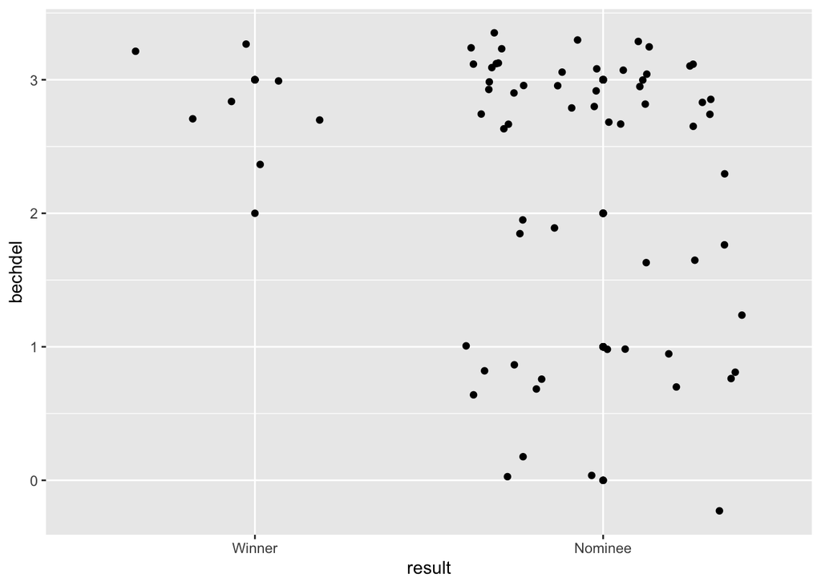

### Violin H2

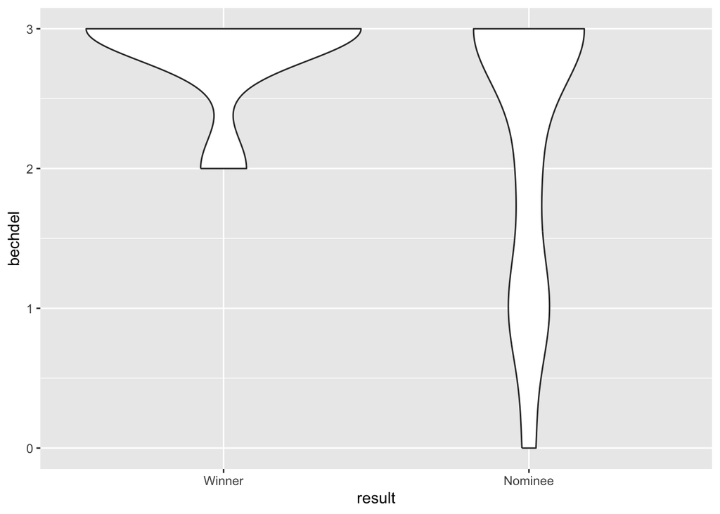

### Boxplot H2

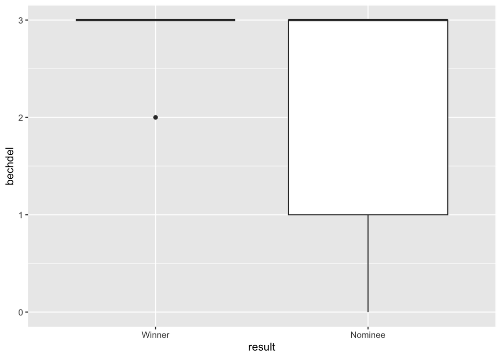

### Spearman Test H2

```
##
##  Spearman's rank correlation rho
##
## data:  bechdel and result_coded
## S = 59275, p-value = 0.1388
## alternative hypothesis: true rho is not equal to 0
## sample estimates:
##        rho
## -0.1827487
```

### Findings H2

There is no real correlation between Bechdel Test criteria passed and winning the Academy Award Best Picture among Academy Award Best Picture nominees, because p = 0.139. PLEASE CHECK.

# Hypothesis 3

H3 Of Best Picture nominees, winners of the Academy Award for Best Picture are more likely to score a higher level of violence.

### Median and Mean H3

```
## # A tibble: 2 × 5
##   result      n   Mdn     M    SD
##   <ord>   <int> <dbl> <dbl> <dbl>
## 1 Winner      7     2  2.29 1.11
## 2 Nominee    60     2  2.55 0.999
```

### Scatter H3

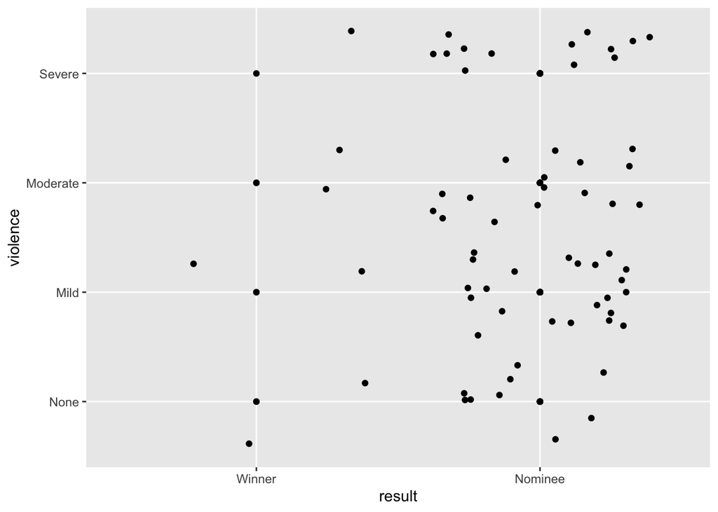

### Violin H3

[figure not shown]

### Boxplot H3

[figure not shown]

### Spearman Test H3

```
##
##  Spearman's rank correlation rho
##
## data:  violence_coded and result_coded
## S = 46230, p-value = 0.5328
## alternative hypothesis: true rho is not equal to 0
## sample estimates:
##        rho
## 0.07754618
```

### Findings H3

There is no real correlation between violence score and winning the Academy Award Best Picture among Academy Award Best Picture nominees, because p = 0.533. PLEASE CHECK.

# Hypothesis 4

H4 The higher the Box Office revenue for an Academy Award for Best Picture nominated film, the more Bechdel Test criteria the film will pass.

### Median and Mean H4

```
## # A tibble: 4 × 5
##   bechdel     n      Mdn          M         SD
##     <dbl> <int>    <dbl>      <dbl>      <dbl>
## 1       0     4       NA        NA         NA
## 2       1    13       NA        NA         NA
## 3       2     8 34831574 160866240  334432862.
## 4       3    42 51471937 265309461. 489957533.
```

### Scatter H4

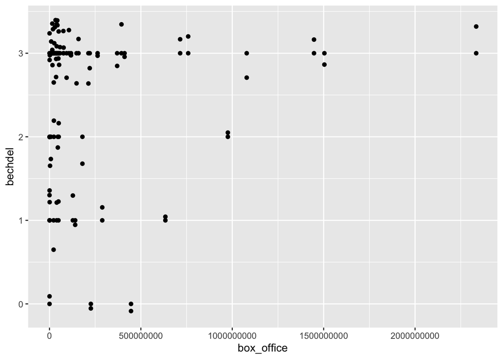

### Violin H4

[figure not shown]

### Boxplot H4

[figure not shown]

### Spearman Test H4

```
##
##  Spearman's rank correlation rho
##
## data:  bechdel and box_office
## S = 36705, p-value = 0.3529
## alternative hypothesis: true rho is not equal to 0
## sample estimates:
##       rho
## 0.1190165
```

### Findings H4

There is no real correlation between Bechdel Test criteria met and Box Office revenue for Academy Award Best Picture nominees, because p = 0.353. PLEASE CHECK.

# Hypothesis 5

H5 The higher the Box Office revenue for an Academy Award for Best Picture nominated film, the film will score a higher level of violence.

### Median and Mean H5

```
## # A tibble: 4 × 5
##   violence     n      Mdn          M         SD
##   <ord>    <int>    <dbl>      <dbl>      <dbl>
## 1 None        11 39458207 195740224. 425661509.
## 2 Mild        24       NA        NA         NA
## 3 Moderate    18       NA        NA         NA
## 4 Severe      14       NA        NA         NA
```

### Scatter H5

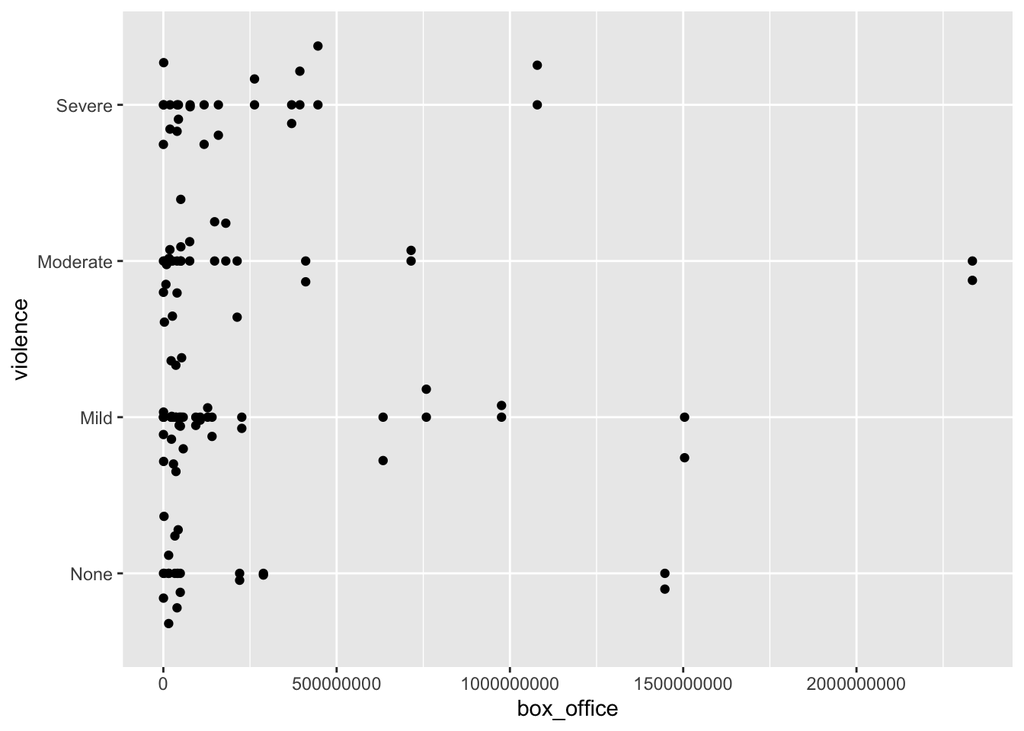

### Violin H5

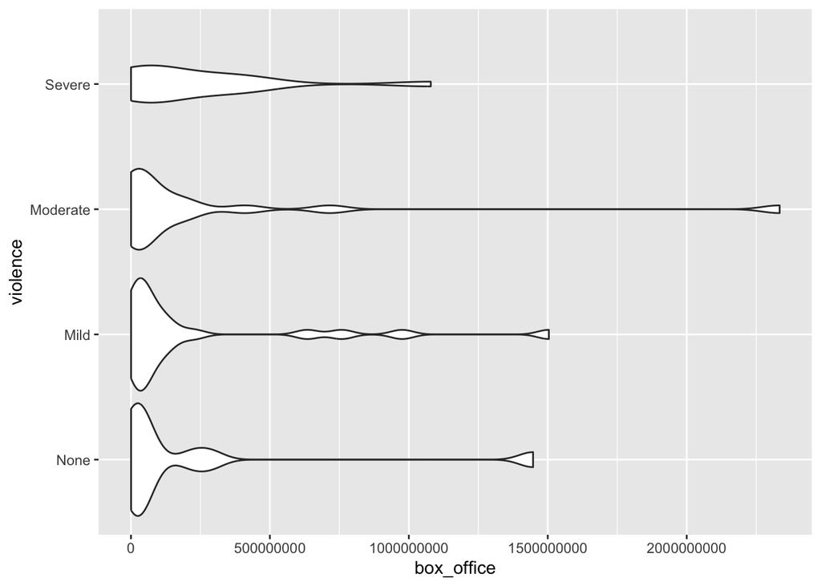

### Boxplot H5

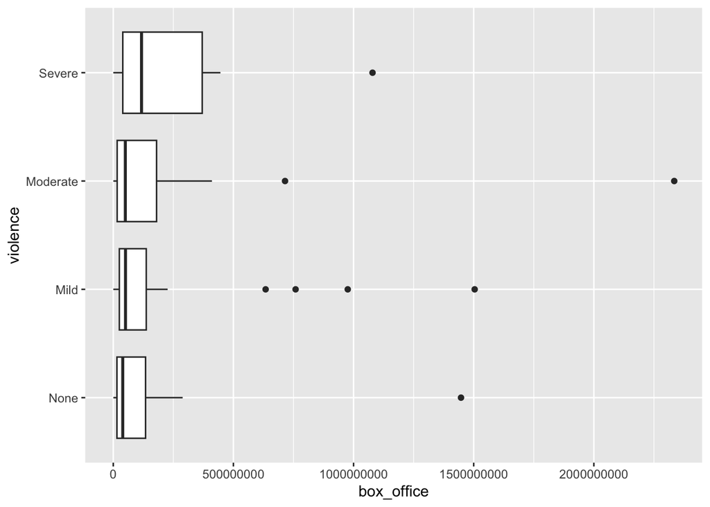

### Spearman Test H5

```
##
##  Spearman's rank correlation rho
##
## data:  violence_coded and box_office
## S = 36711, p-value = 0.3534
## alternative hypothesis: true rho is not equal to 0
## sample estimates:
##       rho
## 0.1188849
```

### Findings H5

There is no real correlation between violence score and Box Office revenue for Academy Award Best Picture nominees, because p = 0.354. PLEASE CHECK.